# Linear Regression 1D: Prediction

## Objective

- How to make the prediction for multiple inputs.
- How to use linear class to build more complex models.
- How to build a custom module.

Created on JupyterLab

**Gradient descent is a method to find the minimum of a function.**

Consider the loss function, if we start off with a random guess for the slope parameter (we use the super script to indicate the guess index). In this case, it is our first guess, so it is zero. We have to move our guess in the positive direction. We can move the slope in that direction by adding a positive number. Examining the sign of of the derivative it is the opposite sign of the number. Therefore we can add a number proportional to the negative of the slope.

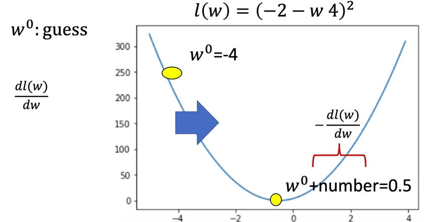

Subtracting the derivative works if we are on the other side of the minimum. In this case, we would like to move in the negative direction. We can move the parameter value to the negative direction by adding a negative number to the parameter. Examining the sine of the derivative, it is the opposite sine of the number. Therefore we can add an amount proportional to the negative of the derivative.

[figure not shown]

In Gradient descent we iteratively calculate this equation. We start off with a guess, we update the parameter by adding a value proportional to the derivative. We update the parameter again. We can express the process as follows. **The parameter eta is the learning rate and tells us how much we need to jump.**

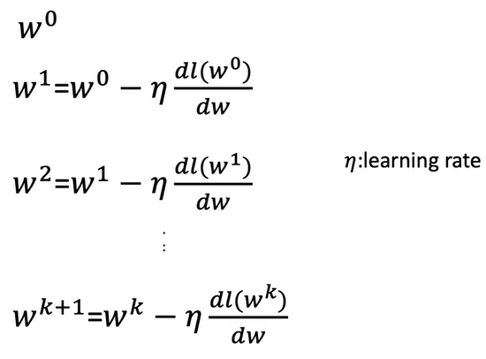

Example:

We start off with a guess of -4. The value for the derivative at -4 is -112. We will use the following value for the learning rate. We calculate the first iteration, the value of the parameter for the first iteration is -1.20. The value for this parameter has a smaller loss, we can see the loss is lower after the first iteration.

For the next iterations, we use the previous parameter estimate of -1.2. We update the parameter value using the update rule The value for the parameter is now -0.64, the loss function is closer to the minimum, the loss value continues to get smaller.

[figure not shown]

Let's see **problems with the learning rate.**

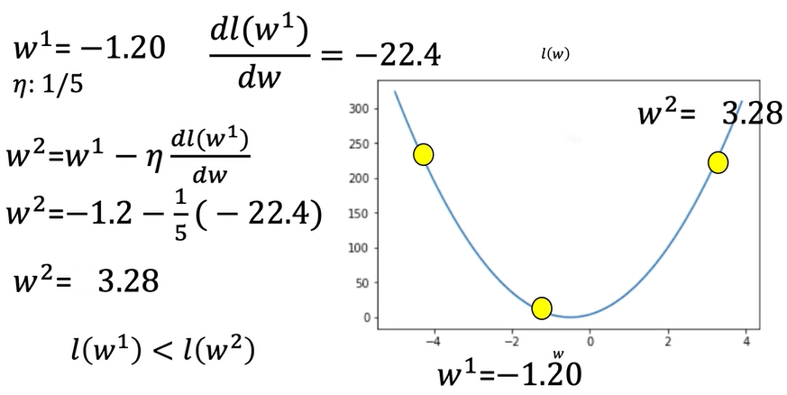

**Sometimes we can set the learning rate too small, let's see what happens when we set the learning rate to 1/240. For every iteration the value of the parameter hardly changes. In this case it will take a lot of iterations to reach the minimum value.**

[figure not shown]

**There are several ways to stop the process of gradient descent.** Let's go over a few popular ways when to stop Gradient Descent.

- **We can run gradient descent, for a set number of iterations.**

In this case we run it for 3 iterations. But for the final iteration we miss the minimum.

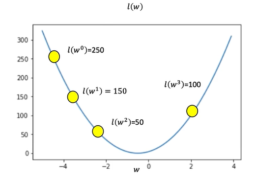

- **Another method to stop gradient descent is to see if the loss starts increasing.**

Let's record a few iterations of gradient descent and record the results in the table. For the first value, the loss is 250. We calculate the first iteration, we see the loss for this iteration is 150 less than the previous iteration. For the second iteration, the loss is also decreasing, we repeat the process. Examining the table we see the loss is 50 and still decreasing, so we keep going. The loss is now 100, this value is larger than 50 so we stop, We use the value of the parameter corresponding to loss of 50, the value is approximately - 2.5.

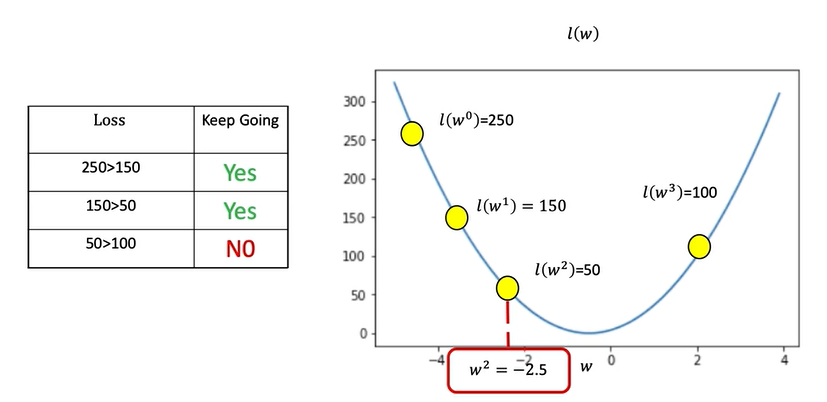

In batch gradient descent, we find the parameters w & b that minimize the entire cost function mathematically.

## Table of Contents

- Prediction
- Class Linear
- Build Custom Modules

## Preparation

```python
# Libraries

import torch
```

## Prediction

Let us create the following expressions:

$b=-1,w=2$

$\hat{y}=-1+2x$

First, define the parameters:

```python
# Define w = 2 and b = -1 for y = wx + b

w = torch.tensor(2.0, requires_grad = True)
b = torch.tensor(-1.0, requires_grad = True)
```

Then, define the function `forward(x, w, b)` makes the prediction:

```python
# Function forward(x) for prediction

def forward(x):
    yhat = w * x + b
    return yhat
```

Let's make the following prediction at *x = 1*

$\hat{y}=-1+2x$

$\hat{y}=-1+2(1)$

```python
# Predict y = 2x - 1 at x = 1

x = torch.tensor([[1.0]])
yhat = forward(x)
print("The prediction: ", yhat)
```

```
The prediction:  tensor([[1.]], grad_fn=<AddBackward0>)
```

Now, let us try to make the prediction for multiple inputs:

[figure not shown]

Let us construct the `x` tensor first. Check the shape of `x`.

```python
# Create x Tensor and check the shape of x tensor

x = torch.tensor([[1.0], [2.0]])
print("The shape of x: ", x.shape)
```

```
The shape of x:  torch.Size([2, 1])
```

Now make the prediction:

```python
# Make the prediction of y = 2x - 1 at x = [1, 2]

yhat = forward(x)
print("The prediction: ", yhat)
```

```
The prediction:  tensor([[1.],
        [3.]], grad_fn=<AddBackward0>)
```

The result is the same as what it is in the image above.

Make a prediction of the following `x` tensor using the `w` and `b` from above.

```python
# Practice: Make a prediction of y = 2x - 1 at x = [[1.0], [2.0], [3.0]]

x = torch.tensor([[1.0], [2.0], [3.0]])

yhat = forward(x)
print("The prediction: ", yhat)
```

```
The prediction:  tensor([[1.],
        [3.],
        [5.]], grad_fn=<AddBackward0>)
```

## Class Linear

The linear class can be used to make a prediction. We can also use the linear class to build more complex models. Let's import the module:

```python
# Import Class Linear

from torch.nn import Linear
```

Set the random seed because the parameters are randomly initialized:

```python
# Set random seed

torch.manual_seed(1)
```

```
<torch._C.Generator at 0x7f861cc47d50>
```

Let us create the linear object by using the constructor. **The parameters are randomly created.** Let us print out to see what *w* and *b*. The parameters of an `torch.nn.Module` model are contained in the model’s parameters accessed with `lr.parameters()`:

```python
# Create Linear Regression Model, and print out the parameters

lr = Linear(in_features=1, out_features=1, bias=True)
print("Parameters w and b: ", list(lr.parameters()))
```

```
Parameters w and b:  [Parameter containing:
tensor([[0.5153]], requires_grad=True), Parameter containing:
tensor([-0.4414], requires_grad=True)]
```

This is equivalent to the following expression:

$b=-0.44, w=0.5153$

$\hat{y}=-0.44+0.5153x$

A method `state_dict()` Returns a Python dictionary object corresponding to the layers of each parameter tensor.

```python
print("Python dictionary: ",lr.state_dict())
print("keys: ",lr.state_dict().keys())
print("values: ",lr.state_dict().values())
```

```
Python dictionary:  OrderedDict([('weight', tensor([[0.5153]])), ('bias', tensor([-0.4414]))])
keys:  odict_keys(['weight', 'bias'])
values:  odict_values([tensor([[0.5153]]), tensor([-0.4414])])
```

The keys correspond to the name of the attributes and the values correspond to the parameter value.

```python
print("weight:",lr.weight)
print("bias:",lr.bias)
```

```
weight: Parameter containing:
tensor([[0.5153]], requires_grad=True)
bias: Parameter containing:
tensor([-0.4414], requires_grad=True)
```

Now let us make a single prediction at *x = [[1.0]]*.

```python
# Make the prediction at x = [[1.0]]

x = torch.tensor([[1.0]])
yhat = lr(x)
print("The prediction: ", yhat)
```

```
The prediction:  tensor([[0.0739]], grad_fn=<AddmmBackward0>)
```

Similarly, you can make multiple predictions:

[figure not shown]

Use model `lr(x)` to predict the result.

```python
# Create the prediction using linear model

x = torch.tensor([[1.0], [2.0]])
yhat = lr(x)
print("The prediction: ", yhat)
```

```
The prediction:  tensor([[0.0739],
        [0.5891]], grad_fn=<AddmmBackward0>)
```

Make a prediction of the following `x` tensor using the linear regression model `lr`.

```python
# Practice: Use the linear regression model object lr to make the prediction.

x = torch.tensor([[1.0],[2.0],[3.0]])

x=torch.tensor([[1.0],[2.0],[3.0]])
yhat = lr(x)
print("The prediction: ", yhat)
```

```
The prediction:  tensor([[0.0739],
        [0.5891],
        [1.1044]], grad_fn=<AddmmBackward0>)
```

## Build Custom Modules

Now, let's build a custom module. We can make more complex models by using this method later on.

First, import the following library.

```python
# Library for this section

from torch import nn
```

Now, let us define the class:

```python
# Customize Linear Regression Class

class LR(nn.Module):

    # Constructor
    def __init__(self, input_size, output_size):

        # Inherit from parent
        super(LR, self).__init__()
        self.linear = nn.Linear(input_size, output_size)

    # Prediction function
    def forward(self, x):
        out = self.linear(x)
        return out
```

Create an object by using the constructor. Print out the parameters we get and the model.

```python
# Create the linear regression model. Print out the parameters.

lr = LR(1, 1)
print("The parameters: ", list(lr.parameters()))
print("Linear model: ", lr.linear)
```

```
The parameters:  [Parameter containing:
tensor([[-0.1939]], requires_grad=True), Parameter containing:
tensor([0.4694], requires_grad=True)]
Linear model:  Linear(in_features=1, out_features=1, bias=True)
```

Let us try to make a prediction of a single input sample.

```python
# Try our customize linear regression model with single input

x = torch.tensor([[1.0]])
yhat = lr(x)
print("The prediction: ", yhat)
```

```
The prediction:  tensor([[0.2755]], grad_fn=<AddmmBackward0>)
```

Now, let us try another example with multiple samples.

```python
# Try our customize linear regression model with multiple input

x = torch.tensor([[1.0], [2.0]])
yhat = lr(x)
print("The prediction: ", yhat)
```

```
The prediction:  tensor([[0.2755],
        [0.0816]], grad_fn=<AddmmBackward0>)
```

the parameters are also stored in an ordered dictionary :

```python
print("Python dictionary: ", lr.state_dict())
print("keys: ",lr.state_dict().keys())
print("values: ",lr.state_dict().values())
```

```
Python dictionary:  OrderedDict([('linear.weight', tensor([[-0.1939]])), ('linear.bias', tensor([0.4694]))])
keys:  odict_keys(['linear.weight', 'linear.bias'])
values:  odict_values([tensor([[-0.1939]]), tensor([0.4694])])
```

Create an object `lr1` from the class we created before and make a prediction by using the following tensor:

```python
# Practice: Use the LR class to create a model and make a prediction of the following tensor.

x = torch.tensor([[1.0], [2.0], [3.0]])

x=torch.tensor([[1.0],[2.0],[3.0]])
lr1=LR(1,1)
yhat=lr(x)
yhat
```

```
tensor([[ 0.2755],
        [ 0.0816],
        [-0.1122]], grad_fn=<AddmmBackward0>)
```

# Linear Regression 1D: Training One Parameter

## Objective

- How to create cost or criterion function using MSE (Mean Square Error).

## Table of Contents

- Make Some Data
- Create the Model and Cost Function (Total Loss)
- Train the Model

## Preparation

```python
# Libraries

import numpy as np
import matplotlib.pyplot as plt
```

The class `plot_diagram` helps us to visualize the data space and the parameter space during training and has nothing to do with PyTorch.

```python
# The class for plotting

class plot_diagram():

    # Constructor
    def __init__(self, X, Y, w, stop, go = False):
        start = w.data
        self.error = []
        self.parameter = []
        print(type(X.numpy()))
        self.X = X.numpy()

        self.Y = Y.numpy()
        self.parameter_values = torch.arange(start, stop)
        self.Loss_function = [criterion(forward(X), Y) for w.data in self.parameter_values]
        w.data = start

    # Executor
    def __call__(self, Yhat, w, error, n):
        self.error.append(error)
        self.parameter.append(w.data)
        plt.subplot(212)
        plt.plot(self.X, Yhat.detach().numpy())
        plt.plot(self.X, self.Y,'ro')
        plt.xlabel("A")
        plt.ylim(-20, 20)
        plt.subplot(211)
        plt.title("Data Space (top) Estimated Line (bottom) Iteration " + str(n))
        # Convert lists to PyTorch tensors
        parameter_values_tensor = torch.tensor(self.parameter_values)
        loss_function_tensor = torch.tensor(self.Loss_function)

        # Plot using the tensors
        plt.plot(parameter_values_tensor.numpy(), loss_function_tensor.numpy())

        plt.plot(self.parameter, self.error, 'ro')
        plt.xlabel("B")
        plt.figure()

    # Destructor
    def __del__(self):
        plt.close('all')
```

## Make Some Data

Import PyTorch library:

```python
# Import the library PyTorch

#import torch
```

Generate values from -3 to 3 that create a line with a slope of -3. This is the line you will estimate.

```python
# Create the f(X) with a slope of -3

X = torch.arange(-3, 3, 0.1).view(-1, 1)
f = -3 * X
```

Let us plot the line.

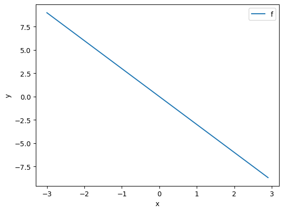

```python
# Plot the line with blue

plt.plot(X.numpy(), f.numpy(), label = 'f')
plt.xlabel('x')
plt.ylabel('y')
plt.legend()
plt.show()
```

Let us add some noise to the data in order to simulate the real data. Use `torch.randn(X.size())` to generate Gaussian noise that is the same size as `X` and has a standard deviation opf 0.1.

```python
# Add some noise to f(X) and save it in Y

Y = f + 0.1 * torch.randn(X.size())
```

Plot the `Y`:

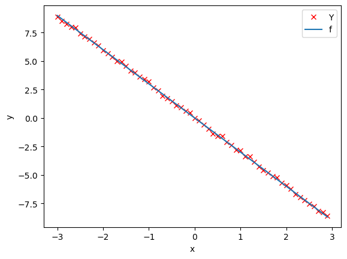

```python
# Plot the data points

plt.plot(X.numpy(), Y.numpy(), 'rx', label = 'Y')

plt.plot(X.numpy(), f.numpy(), label = 'f')
plt.xlabel('x')
plt.ylabel('y')
plt.legend()
plt.show()
```

## Create the Model and Cost Function (Total Loss)

In this section, let us create the model and the cost function (total loss) we are going to use to train the model and evaluate the result.

First, define the `forward` function $y=w*x$.

```python
# Create forward function for prediction

def forward(x):
    return w * x
```

**Define the cost or criterion function using MSE (Mean Square Error):**

```python
# Create the MSE function for evaluate the result.

def criterion(yhat, y):
    return torch.mean((yhat - y) ** 2)
```

Define the learning rate `lr` and an empty list `LOSS` to record the loss for each iteration:

```python
# Create Learning Rate and an empty list to record the loss for each iteration

lr = 0.1
LOSS = []
```

Now, we create a model parameter by setting the argument `requires_grad` to `True` because the system must learn it.

```python
w = torch.tensor(-10.0, requires_grad = True)
```

Create a `plot_diagram` object to visualize the data space and the parameter space for each iteration during training:

```python
gradient_plot = plot_diagram(X, Y, w, stop = 5)
```

```
<class 'numpy.ndarray'>
```

## Train the Model

Let us define a function for training the model. The steps will be described in the comments.

```python
# Define a function for train the model

def train_model(iter):
    for epoch in range (iter):

        # make the prediction
        Yhat = forward(X)

        # calculate the iteration
        loss = criterion(Yhat,Y)

        # plot the diagram for us to have a better idea
        gradient_plot(Yhat, w, loss.item(), epoch)

        # store the loss into list
        LOSS.append(loss.item())

        # backward pass: compute gradient of the loss with respect to all the learnable parameters
        loss.backward()

        # updata parameters
        w.data = w.data - lr * w.grad.data

        # zero the gradients before running the backward pass
        w.grad.data.zero_()
```

Let us try to run 4 iterations of gradient descent:

**On the first plot (top), the loss function is plotted, with the guess of the parameter *w* (on the x axis) highlighted in red. Gradient descent updates the guess to find the minimum of the loss function.**

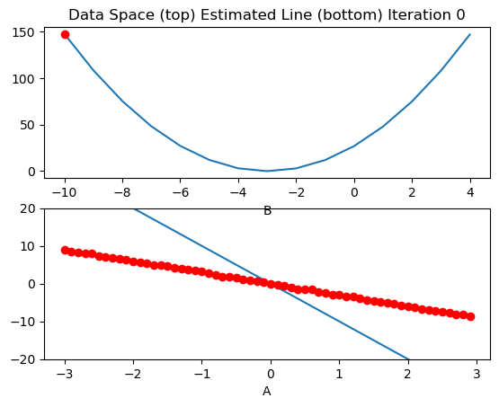

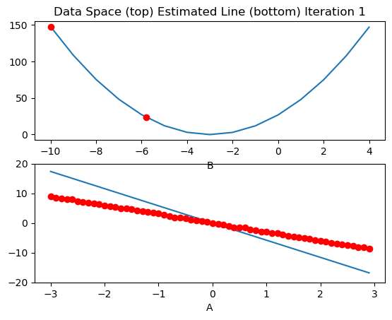

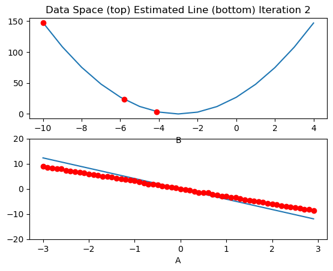

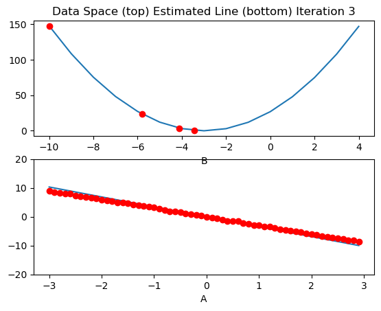

```python
# Give 4 iterations for training the model here.
train_model(4)
```

Plot the cost for each iteration:

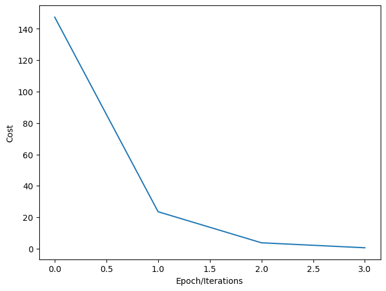

```python
# Plot the loss for each iteration
plt.plot(LOSS)
plt.tight_layout()
plt.xlabel("Epoch/Iterations")
plt.ylabel("Cost")
```

Create a new learnable parameter `w` with an **initial value of -15.0.**

```python
w = torch.tensor(-15.0, requires_grad=True)
```

Create an empty list `LOSS2`:

```python
LOSS2 = []
```

Write your own `my_train_model` function with loss list `LOSS2`. And run it with 4 iterations.

```
<class 'numpy.ndarray'>
```

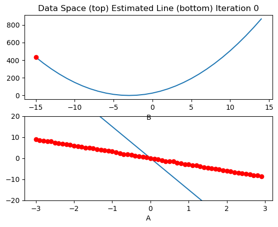

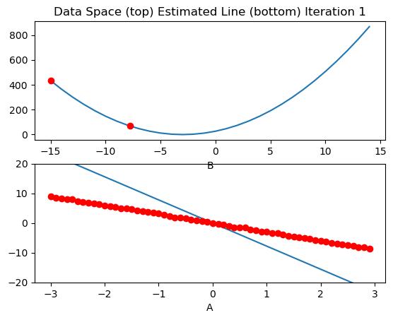

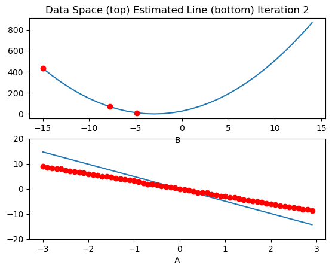

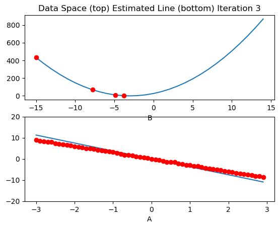

```python
# Practice: Create your own my_train_model

gradient_plot1 = plot_diagram(X, Y, w, stop = 15)

def my_train_model(iter):
    for epoch in range (iter):
        Yhat = forward(X)
        loss = criterion(Yhat,Y)
        gradient_plot1(Yhat, w, loss.item(), epoch)
        LOSS2.append(loss.item())
        loss.backward()
        w.data = w.data - lr * w.grad.data
        w.grad.data.zero_()
my_train_model(4)
```

Plot an overlay of the list `LOSS2` and `LOSS`.

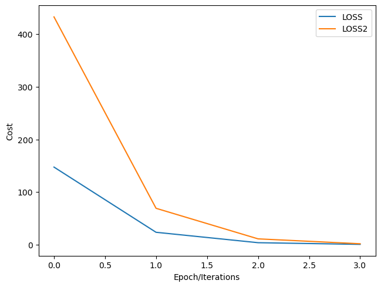

```python
# Practice: Plot the list LOSS2 and LOSS
plt.plot(LOSS, label = "LOSS")
plt.plot(LOSS2, label = "LOSS2")
plt.tight_layout()
plt.xlabel("Epoch/Iterations")
plt.ylabel("Cost")
plt.legend()
```

We outline that the parameter value is sensitive to initialization (initial value of *w*).

# Linear regression 1D: Training Two Parameters

## Objective

- How to train the model and visualize the loss results.

## Table of Contents

- Make Some Data
- Create the Model and Cost Function (Total Loss)
- Train the Model

## Preparation

```python
# Libraries

import numpy as np
import matplotlib.pyplot as plt
from mpl_toolkits import mplot3d
```

The class `plot_error_surfaces` is just to help you visualize the data space and the parameter space during training and has nothing to do with PyTorch.

```python
# The class for plot the diagram

class plot_error_surfaces(object):

    # Constructor
    def __init__(self, w_range, b_range, X, Y, n_samples = 30, go = True):
        W = np.linspace(-w_range, w_range, n_samples)
        B = np.linspace(-b_range, b_range, n_samples)
        w, b = np.meshgrid(W, B)
        Z = np.zeros((30,30))
        count1 = 0
        self.y = Y.numpy()
        self.x = X.numpy()
        for w1, b1 in zip(w, b):
            count2 = 0
            for w2, b2 in zip(w1, b1):
                Z[count1, count2] = np.mean((self.y - w2 * self.x + b2) ** 2)
                count2 += 1
            count1 += 1
        self.Z = Z
        self.w = w
        self.b = b
        self.W = []
        self.B = []
        self.LOSS = []
        self.n = 0
        if go == True:
            plt.figure()
            plt.figure(figsize = (7.5, 5))
            plt.axes(projection='3d').plot_surface(self.w, self.b, self.Z, rstride = 1, cstride = 1,cmap = 'viridis', edgecolor = 'none')
            plt.title('Cost/Total Loss Surface')
            plt.xlabel('w')
            plt.ylabel('b')
            plt.show()
            plt.figure()
            plt.title('Cost/Total Loss Surface Contour')
            plt.xlabel('w')
            plt.ylabel('b')
            plt.contour(self.w, self.b, self.Z)
            plt.show()

    # Setter
    def set_para_loss(self, W, B, loss):
        self.n = self.n + 1
        self.W.append(W)
        self.B.append(B)
        self.LOSS.append(loss)

    # Plot diagram
    def final_plot(self):
        ax = plt.axes(projection = '3d')
        ax.plot_wireframe(self.w, self.b, self.Z)
        ax.scatter(self.W,self.B, self.LOSS, c = 'r', marker = 'x', s = 200, alpha = 1)
        plt.figure()
        plt.contour(self.w,self.b, self.Z)
        plt.scatter(self.W, self.B, c = 'r', marker = 'x')
        plt.xlabel('w')
        plt.ylabel('b')
        plt.show()

    # Plot diagram
    def plot_ps(self):
        plt.subplot(121)
        plt.ylim
        plt.plot(self.x, self.y, 'ro', label="training points")
        plt.plot(self.x, self.W[-1] * self.x + self.B[-1], label = "estimated line")
        plt.xlabel('x')
        plt.ylabel('y')
        plt.ylim((-10, 15))
        plt.title('Data Space Iteration: ' + str(self.n))

        plt.subplot(122)
        plt.contour(self.w, self.b, self.Z)
        plt.scatter(self.W, self.B, c = 'r', marker = 'x')
        plt.title('Total Loss Surface Contour Iteration' + str(self.n))
        plt.xlabel('w')
        plt.ylabel('b')
        plt.show()
```

## Make Some Data

Import PyTorch:

```python
# Import PyTorch library

#import torch
```

Start with generating values from -3 to 3 that create a line with a slope of 1 and a bias of -1. This is the line that you need to estimate.

```python
# Create f(X) with a slope of 1 and a bias of -1

X = torch.arange(-3, 3, 0.1).view(-1, 1)
f = 1 * X - 1
```

Now, add some noise to the data:

```python
# Add noise

Y = f + 0.1 * torch.randn(X.size())
```

Plot the line and `Y` with noise:

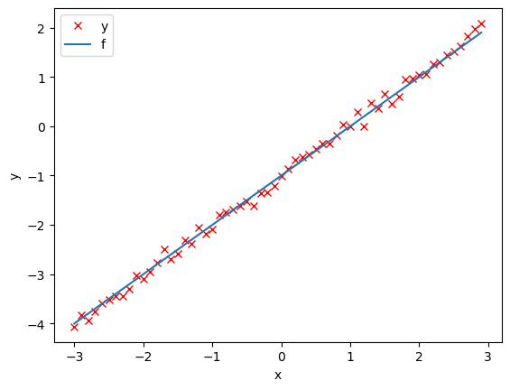

```python
# Plot out the line and the points with noise

plt.plot(X.numpy(), Y.numpy(), 'rx', label = 'y')
plt.plot(X.numpy(), f.numpy(), label = 'f')
plt.xlabel('x')
plt.ylabel('y')
plt.legend()
```

## Create the Model and Cost Function (Total Loss)

Define the `forward` function:

```python
# Define the forward function

def forward(x):
    return w * x + b
```

Define the cost or criterion function (MSE):

```python
# Define the MSE Loss function

def criterion(yhat,y):
    return torch.mean((yhat-y)**2)
```

Create a `plot_error_surfaces` object to visualize the data space and the parameter space during training:

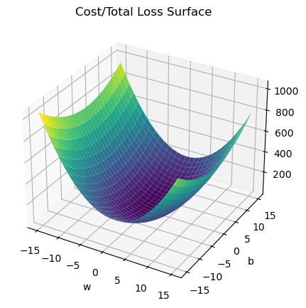

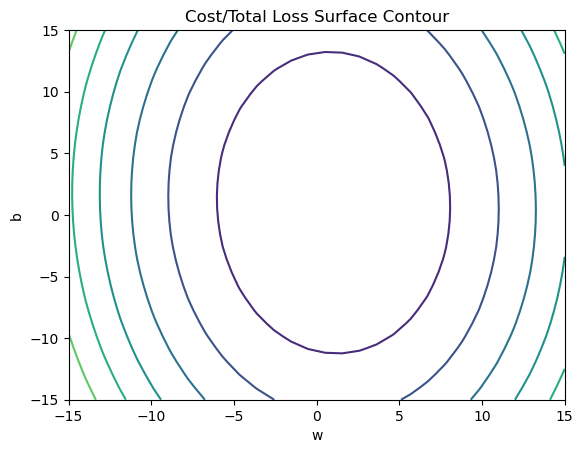

```python
# Create plot_error_surfaces for viewing the data
#15 : range for w and b
#30 samples
#The loss function represents the MSE
get_surface = plot_error_surfaces(15, 15, X, Y, 30)
```

## Train the Model

Create model parameters `w`, `b` by setting the argument `requires_grad` to True because we must learn it using the data.

```python
# Define the parameters w, b for y = wx + b

w = torch.tensor(-15.0, requires_grad = True)
b = torch.tensor(-10.0, requires_grad = True)
```

Set the learning rate to 0.1 and create an empty list `LOSS` for storing the loss for each iteration.

```python
# Define learning rate and create an empty list for containing the loss for each iteration.

lr = 0.1
LOSS = []
```

Define `train_model` function for train the model.

```python
# The function for training the model

def train_model(iter):

    # Loop
    for epoch in range(iter):

        # make a prediction
        Yhat = forward(X)

        # calculate the loss
        loss = criterion(Yhat, Y)

        # Section for plotting
        get_surface.set_para_loss(w.data.tolist(), b.data.tolist(), loss.tolist())
        if epoch % 3 == 0:
            get_surface.plot_ps()

        # store the loss in the list LOSS
        LOSS.append(loss)

        # backward pass: compute gradient of the loss with respect to all the learnable parameters
        loss.backward()

        # update parameters slope and bias
        w.data = w.data - lr * w.grad.data
        b.data = b.data - lr * b.grad.data

        # zero the gradients before running the backward pass
        w.grad.data.zero_()
        b.grad.data.zero_()
```

Run 15 iterations of gradient descent: **bug** data space is 1 iteration ahead of parameter space

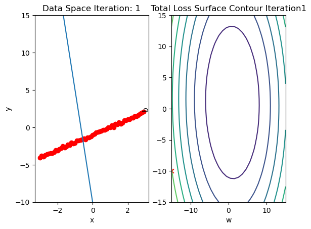

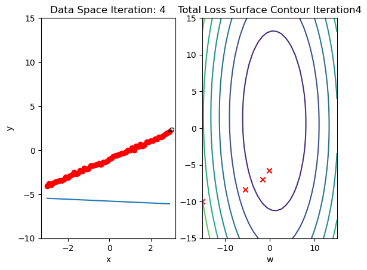

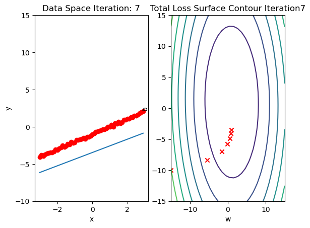

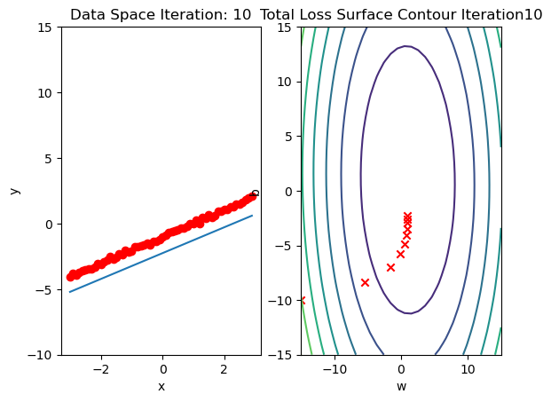

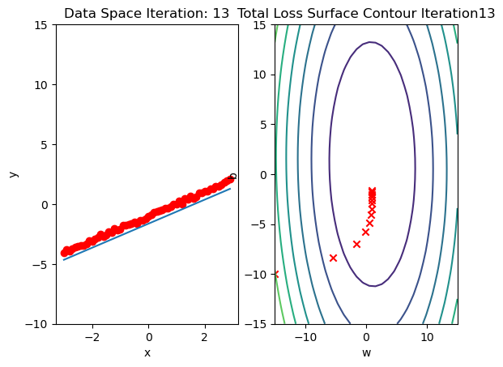

```python
# Train the model with 15 iterations

train_model(15)
```

Plot total loss/cost surface with loss values for different parameters in red:

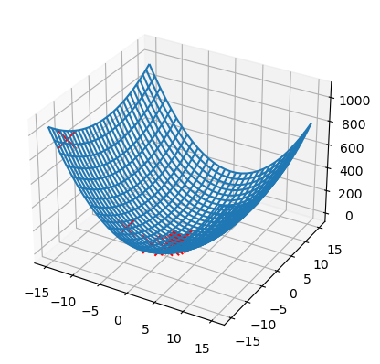

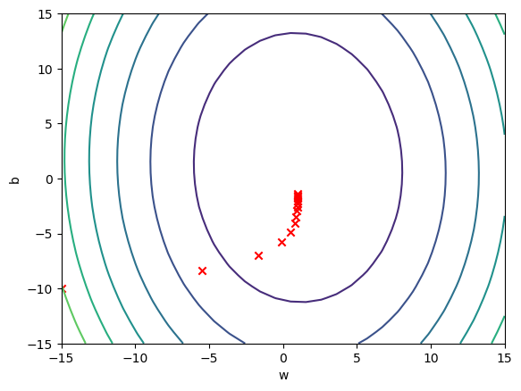

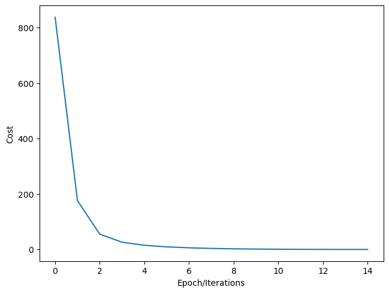

```python
# Plot out the Loss Result

get_surface.final_plot()
LOSS= [ loss.detach().numpy() for loss in LOSS]
plt.plot(LOSS)
plt.tight_layout()
plt.xlabel("Epoch/Iterations")
plt.ylabel("Cost")
```